# Introduction to Web Mapping for Public Health

Workshop at CeSHHAR Zimbabwe

Presenter: Carrie Fahey, MPH

June 15, 2017

[**<< Workshop Home**](https://cafahey.github.io/gis)

# Case Study: GIS and VMMC in Tanzania

[Covering the Last Kilometer: Using GIS to Scale-Up Voluntary Medical Male Circumcision Services in Tanzania](http://www.ghspjournal.org/content/3/3/503.full)

by Hally Mahler, Sarah Searle, Marya Plotkin, Yusuph Kulindwa, Seth Greenberg, Erick Mlanga, Emmanuel Njeuhmeli, and Gissenje Lijae

*Global Health Science and Practice* (2015)

## Purpose of the article

This article describes the Tanzania VMMC program’s evolving use of geographic information systems (GIS) technology to strategically plan and implement outreach campaigns in order to extend VMMC services to remote rural areas and achieve rapid scale-up.

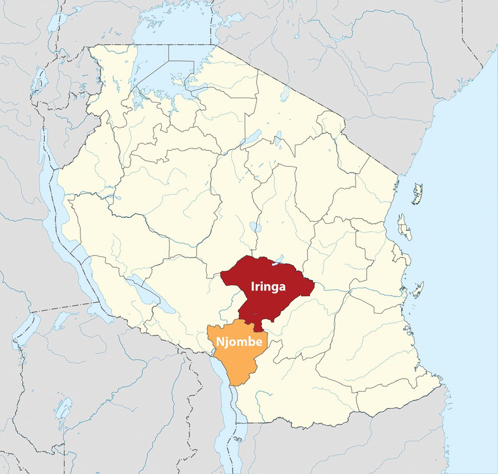

[Figure 1.](http://www.ghspjournal.org/content/3/3/503/F1.large.jpg) Voluntary Medical Male Circumcision Focus Regions in Tanzania. Map image adapted from Sémhur/Wikimedia Commons/CC-BY-SA-3.0.

The authors describe two phases of mapping:

1. Static maps
2. Interactive maps

## Static Maps

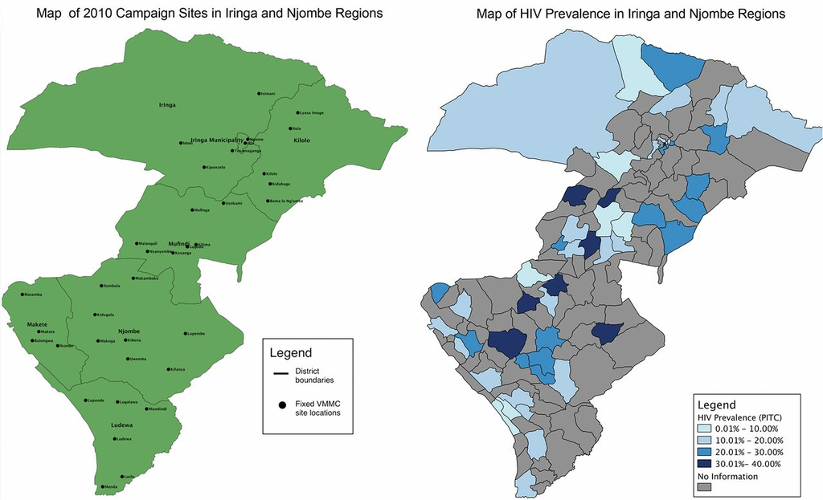

[Figure 2.](http://www.ghspjournal.org/content/3/3/503/F2.large.jpg) Maps Used to Plan 2012 Voluntary Medical Male Circumcision Outreach Campaign, Iringa and Njombe Regions, Tanzania

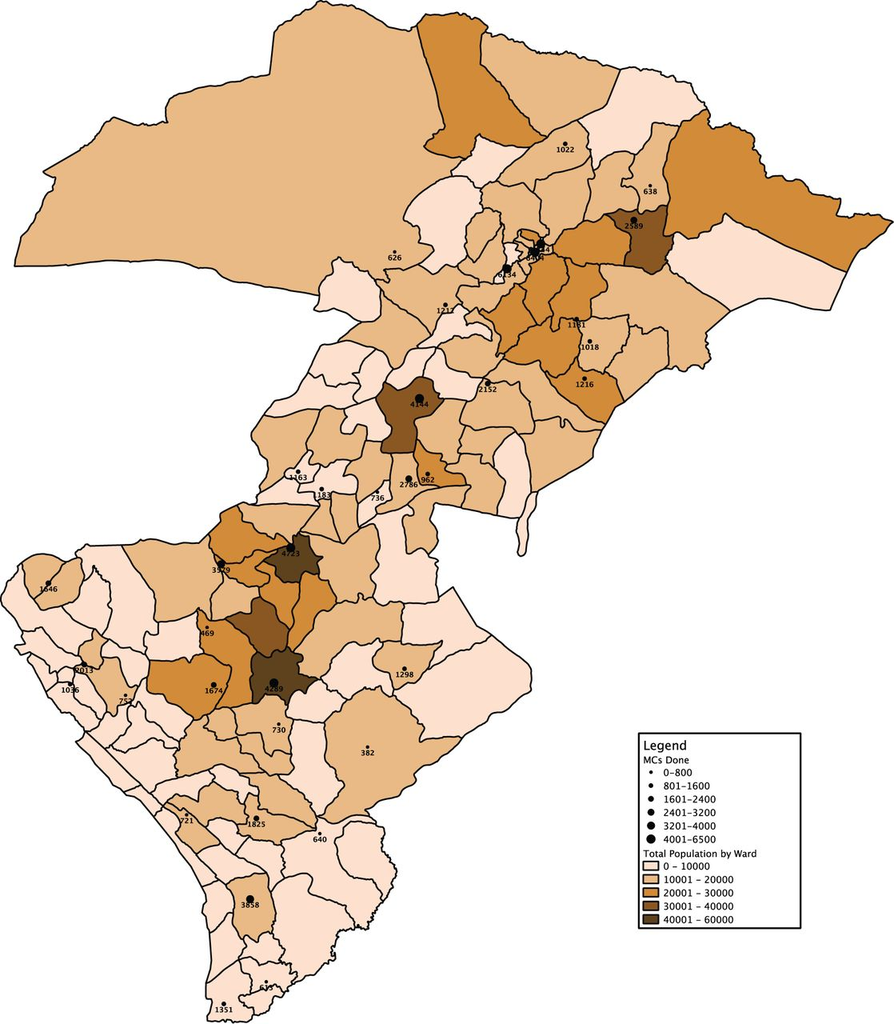

[Figure 3.](http://www.ghspjournal.org/content/3/3/503/F3.large.jpg) Map of Total Population Layered With Number of Voluntary Medical Male Circumcisions Performed, by Ward, Iringa and Njombe Regions, Tanzania, April 2012

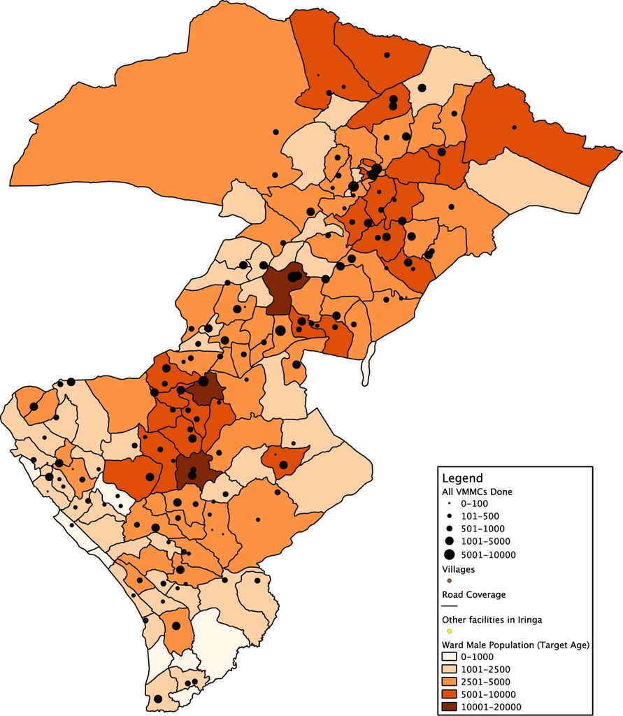

[Figure 4.](http://www.ghspjournal.org/content/3/3/503/F4.large.jpg) Map of Male Population Ages 10-49 Layered With Number of Voluntary Medical Male Circumcisions (VMMCs) Performed, by Ward, Iringa and Njombe Regions, Tanzania, August 2013

### Limitations of static maps

1. Display a restricted amount of information
2. Require time and specialized skills to update
3. Infrequently updated

## Interactive Web Maps

1. Allow for interaction with data on the map
   - Zoom in, click on features, view selected data
2. Turn different data on/off, compare data
3. Can incorporate detailed data (e.g. satellite imagery)
4. Can dynamically update

[figure not shown]

[Figure 5.](http://www.ghspjournal.org/content/3/3/503/F5.large.jpg) Interactive Map Displaying Information on Manda Health Centre Site, Njombe Region, Tanzania

[figure not shown]

[Figure 6.](http://www.ghspjournal.org/content/3/3/503/F6.large.jpg) Interactive Map Displaying Satellite Imagery of Facility Layout

[figure not shown]

[Figure 7.](http://www.ghspjournal.org/content/3/3/503/F7.large.jpg) Interactive Map of Facilities Performing 0-1,000 Voluntary Medical Male Circumcisions (VMMCs) and Quality of Roads. VMMCs by facility shown as yellow (no VMMCs) and pink (<1,000 VMMCs) circles.

### Limitations of interactive web maps

1. Software service agreements may hinder data privacy
2. Difficult to ensure data security in cloud-based systems
3. Require Internet connection

## Conclusion

The use of GIS to collect and analyze the geographic distribution of the focus population, along with the availability of VMMC services in previously unreached areas, enabled more effective scale-up to rural lower-level health facilities by providing project staff with data that could be used to identify ideal sites for outreach.

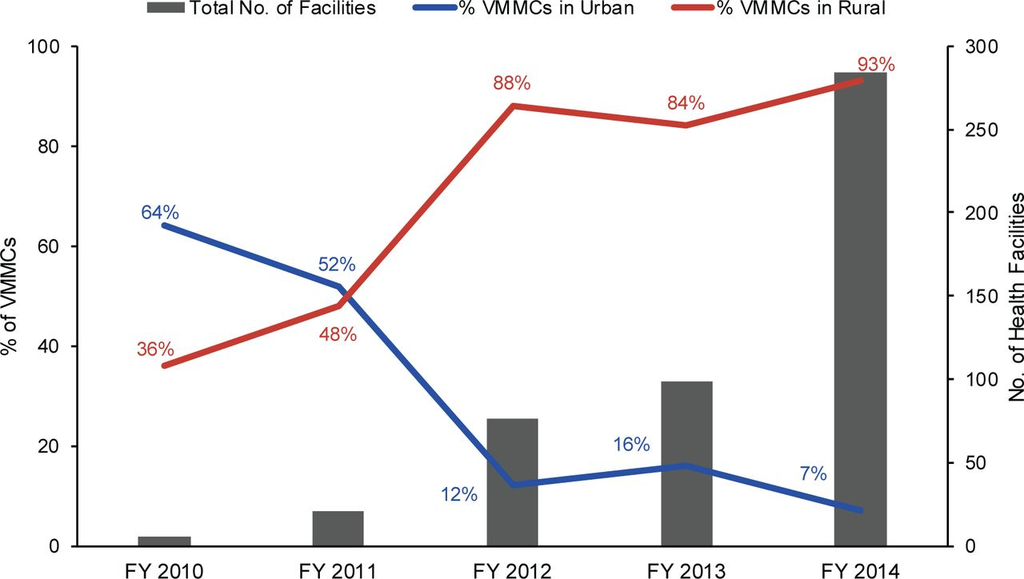

[Figure 8.](http://www.ghspjournal.org/content/3/3/503/F8.large.jpg) Percentage of VMMCs Performed in Urban Versus Rural Health Facilities and Total Number of Health Facilities Reached, by Fiscal Year, Iringa and Njombe Regions, Tanzania, 2010-2014.

# Web Mapping Examples

## Risk and Exposure Assessment

- [Spatial epidemiology of Ebola virus disease](https://vizhub.healthdata.org/ebola/)
- [Global Risk Data Platform](http://preview.grid.unep.ch/index.php?preview=map&lang=eng)

## Monitoring and Evaluation

- [Nigeria Health Map](https://vizhub.healthdata.org/health-map/nigeria)
- [HealthMap.org](http://www.healthmap.org/en/)
- [WHO PMTCT Map](http://gamapserver.who.int/gho/interactive_charts/hiv/pmtct/atlas.html)

## Health Services Delivery Planning

- [UDSMapper](https://udsmapper.org)
- [AIDSVu](https://aidsvu.org/map/)
- [GET ON THE MAP! for AIDS PREVENTION in South Africa](https://worldmap.harvard.edu/womenintheworld-southafrica/)

[**<< Workshop Home**](https://cafahey.github.io/gis)